# Курсовая работа по теории вероятностей и математической статистике

- Студент: Перевозчиков Георгий
- Группа: М8О-305Б-17
- Руководитель: Семенихин К. В

## Задача 1

[figure not shown]

### Решение

1. Определим вариативные параметры и импортируем необходимые библиотеки:
- `n` - колличкство измерений
- `h` - временной шаг
- `v` - линейная скорость
- `sigma` - среднеквадратическое отклонение
- `disp` - дисперсия
- `y0` - начальное расстояние от наблюдателя (самолет над наблюдателем)
- `t` - вектор времени: $t_i = h*i$
- `x` - вектор координат самолета в каждый момент времени t: $x_i = v*t_t$
- `r` - вектор дальностьи а каждый момент времени
- `norm_errors` - ошибки наблюдения: их можно сгенерировать с помошью `np.random.normal(0, sigma)`
- `alpha` - уровень значимости

```python
# импорт библиотек
import numpy as np
import matplotlib.pyplot as plt
```

```python
# вариативные параметры
n = 20
h = 2
v = 100
sigma = 100
disp = sigma**2
y0 = 10000
t = np.arange(0, h*n, h)
x = v*t
r = np.sqrt(x**2 + y0**2)
norm_errors = np.random.normal(0, sigma, t.shape[0])
alpha = 0.01
```

1. Построим график

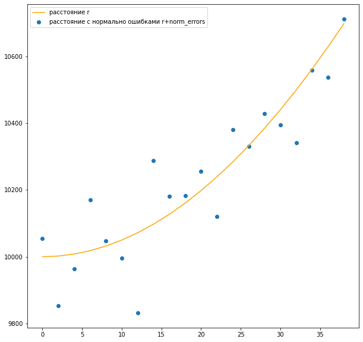

```python
plt.figure(figsize=(10,10))
plt.plot(t, r, label = "расстояние r", color= "orange")
plt.scatter(t, r+norm_errors, label = "расстояние с нормально ошибками r+norm_errors")
plt.legend()
plt.show()
```

1. постотрим на вектор расстояния и расстояния с ошибками

```python
print('расстояние:\n', r)
print('расстояние c ошибками:\n', r+norm_errors)
```

```
расстояние:
 [10000.         10001.99980004 10007.99680256 10017.98382909
 10031.94896319 10049.87562112 10071.74264961 10097.52444909
 10127.19112094 10160.7086367  10198.03902719 10239.14058894
 10283.96810575 10332.47308247 10384.6039886  10440.30650891
 10499.52379873 10562.19674121 10628.26420447 10697.66329625]
расстояние c ошибками:
 [10054.4185668   9853.76284322  9964.49142514 10171.18985532
 10047.98334741  9996.39222432  9831.71965145 10287.11503691
 10181.41364269 10183.26181203 10255.0070167  10120.45837768
 10379.65089657 10331.23327909 10427.88464285 10394.63628785
 10341.64344827 10558.75466767 10537.00432824 10711.98920701]
```

## Задача 2

[figure not shown]

### Решение

1. Определим уравнение простой линейной регрессии (в матричной форме):

$$ Y = A\cdot\theta+W $$

где:

- `𝑌` - вектор наблюдений (n x 1)
- `𝐴` - регрессионная матрица (n x 2): первый столбец - единичный, второй - значения параметра 𝑡
- `𝜃` - вектор (2 x 1) неизвестных параметров (весов модели)
- `𝑊` - матрица (n x 1) ошибок наблюдений
- `n` - количество наблюдений

$$ A = \begin{bmatrix} 1 & t_{1}\\ \vdots & \vdots\\ 1 & t_{n} \end{bmatrix};\ \theta = \begin{bmatrix} \theta_{1}\\ \theta_{2} \end{bmatrix} $$

1. Заметим что необходимое и достаточное условиене смещенности оценки выполняется, т.к. нет систематических ошибок: $$MW=0$$
2. Ошибки независимы, значит модель оптимальна: $$ I_{n}= \begin{bmatrix} 1 & \dots & 1 \\ \vdots & \ddots & \vdots \\ 0 & \dots & 1 \end{bmatrix}\ \Rightarrow 𝐷𝑊_k=𝜎^2=𝑐𝑜𝑛𝑠𝑡 $$
3. Оценим вектор параметров (весов) по методу наименьших квадратов: $$ \theta:(Y-A\cdot\theta)^2 = min_{\theta} $$
4. Если $\exists(A^TA)^{-1}$: $$ \hat{\theta} = \underset{\theta}{\mathrm{argmin}}(Y-A\theta)^2=(A^TA)^{-1}A^TY $$
5. Зададим доверительный интервал: $$ P(\hat{r}(t)-u_{\alpha}\sqrt{D_r(t)}\leq\hat{r}(t)+u_{\alpha}\sqrt{D_r(t)}=1-\alpha $$

Где:

- $\hat{Y} = A\cdot\hat{\theta}$ - оценка вектора наблюдений 𝑌.
1. Выполним необходимые для решения задачи рассчеты, причем:
- `n` - колличество измерений
- `A` - регрессионная матрицa $A$
- `Y` - вектор наблюдений $Y$
- `theta_hat` - МНК оценка параметров $\hat{\theta}$
- `theta_1_hat` - Первый параметр $\hat{\theta}_1$
- `theta_2_hat` - Второй параметр $\hat{\theta}_2$
- `r_hat` - МНК-оценки $\hat{r}$
- `s` - дисперсия МНК-оценки $D_r(t)$
- `upper_bound`, `lower_bound` - Границы доверительного интервала
- `E` - остатки (ошибка) МНК-оценки
- `u_a` - квантиль нормального распределения

```python
n = r.size
u_a = 2.326
A = np.matrix(np.concatenate((np.ones(shape = (n, 1), dtype = int), t.reshape(n,1)), axis=1))
Y = np.matrix(r+norm_errors).T
theta_hat = np.dot(np.dot(np.linalg.inv(np.dot(A.T,A)),A.T), Y)
theta_1_hat = float(theta_hat[0,0])
theta_2_hat = float(theta_hat[1,0])
r_hat = theta_1_hat + t * theta_2_hat
s = np.power(np.sum(r - r_hat),2)/(n-2)
upper_bound = r_hat + u_a*np.sqrt(s)
lower_bound = r_hat - u_a*np.sqrt(s)
E = r+norm_errors - r_hat
```

1. Построим график

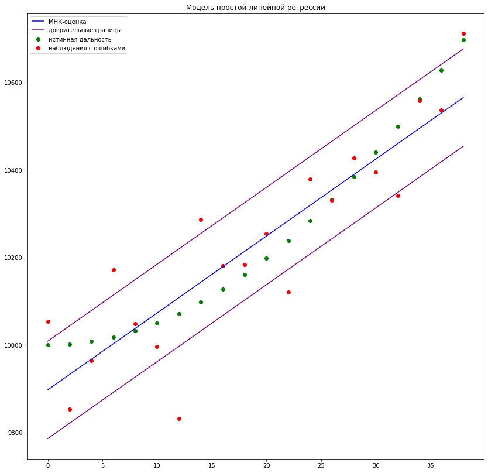

```python
plt.figure(figsize=(14,14))
plt.title("Модель простой линейной регрессии")
plt.scatter(t,r, label = "истинная дальность", color = 'green')
plt.scatter(t,r+norm_errors, label = "наблюдения с ошибками", color = 'red')
plt.plot(t, r_hat, label = "МНК-оценка", color = 'blue')
plt.plot(t, upper_bound, label = "доврительные границы", color = 'purple')
plt.plot(t, lower_bound, color = 'purple')
plt.legend()
plt.show()
```

## Задача 3

[figure not shown]

### Решение

1. Решение аналошично предыдущему заданию с той лишб разницей что матрица $A$ и $\theta$ теперь имееют размер (n x 3) и (3 x 1) соответственно:

$$ A = \begin{bmatrix} 1 & t_{1} & \frac{t_{1}^2}{2}\\ \vdots & \vdots & \vdots\\ 1 & t_{n} & \frac{t_{n}^2}{2} \end{bmatrix};\ \theta = \begin{bmatrix} \theta_{1}\\ \theta_{2}\\ \theta_{3} \end{bmatrix} $$

1. Выполним необходимые для решения задачи рассчеты, причем:
- `n` - колличество измерений
- `A` - регрессионная матрицa $A$
- `Y` - вектор наблюдений $Y$
- `theta_hat` - МНК оценка параметров $\hat{\theta}$
- `theta_1_hat` - Первый параметр $\hat{\theta}_1$
- `theta_2_hat` - Второй параметр $\hat{\theta}_2$
- `theta_3_hat` - Третий параметр $\hat{\theta}_3$
- `r_hat` - МНК-оценки $\hat{r}$
- `s` - дисперсия МНК-оценки $D_r(t)$
- `upper_bound`, `lower_bound` - Границы доверительного интервала
- `E2` - остатки (ошибка) МНК-оценки
- `u_a` - квантиль нормального распределени

```python
n = r.size
A = np.matrix(np.concatenate((np.concatenate((np.ones(shape = (n, 1), dtype = int), t.reshape(n,1)), axis=1), ((np.power(t,2))/2).reshape(n,1)), axis = 1))
Y = np.matrix(r+norm_errors).T
theta_hat = np.dot(np.dot(np.linalg.inv(np.dot(A.T,A)),A.T), Y)
theta_1_hat = float(theta_hat[0,0])
theta_2_hat = float(theta_hat[1,0])
theta_3_hat = float(theta_hat[2,0])
r_hat = theta_1_hat + t * theta_2_hat + np.power(t,2) * theta_3_hat/2
s = np.power(np.sum(r-r_hat),2)/(n-2)
upper_bound = r_hat + u_a*np.sqrt(s)
lower_bound = r_hat - u_a*np.sqrt(s)
E2 = r+norm_errors - r_hat
```

1. Построим график

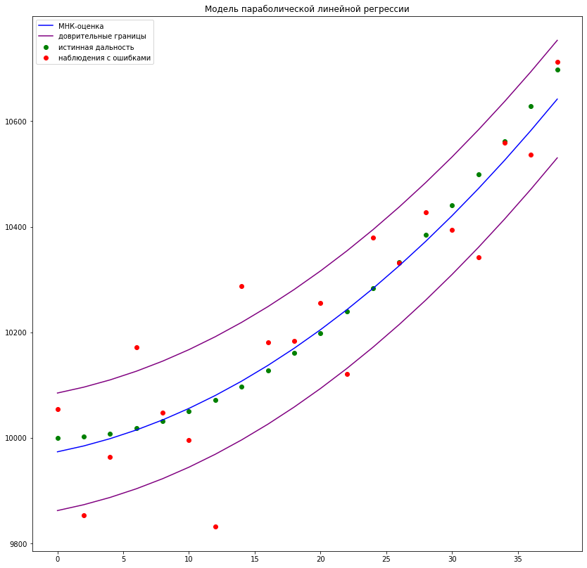

```python
plt.figure(figsize=(14,14))
plt.title("Модель параболической линейной регрессии")
plt.scatter(t,r, label = "истинная дальность", color = 'green')
plt.scatter(t,r+norm_errors, label = "наблюдения с ошибками", color = 'red')
plt.plot(t, r_hat, label = "МНК-оценка", color = 'blue')
plt.plot(t, upper_bound, label = "доврительные границы", color = 'purple')
plt.plot(t, lower_bound, color = 'purple')
plt.legend()
plt.show()
```

## Задача 4

[figure not shown]

### Решение

1. Введем нулевую гепотизу $H_0$: $\theta_{3}=0$
2. Тогда альтернативная гипотиза $H_1$: $\theta_{3}\neq0$
3. Введем статистику: $T = \frac{\hat{\theta}_3}{\sqrt{D[\hat{\theta}_3]}}$
4. Критическая область: $P(-u_{1-\frac{\alpha}{2}}\leq T\leq u_{1-\frac{\alpha}{2}}) = 1 - \alpha$
5. Из свойств теоремы Гаусса-Маркова следует: $M[\hat{\theta}_3] = \theta_3$
6. Произведем рычисления для данной задачи: $$ T\mid_{H_0} = \frac{\hat{\theta}_3}{\sqrt{(\hat{\theta}_3-0)^2}};\ \alpha = 0.01 $$

$$ P(-u_{0.995}\leq \frac{\hat{\theta}_3}{\sqrt{(\hat{\theta}_3-0)^2}} \leq u_{0.995}) = 0.99 \Rightarrow P(-2.58\leq 1 \leq 2.58) $$

При выполнении гипотезы $H_0$, статистика $T$ входит в критическую область, следовательно она верна на уровне значимости $\alpha=0.01$. Значит $\theta_{3}=0$.

## Задача 5

[figure not shown]

## Решение

1. Построим график остатков модели простой линейной регрессии с помощью `plt.scatter(t,E)`
2. С помощью `scipy.stats.norm.pdf(x)` построим график плотности $N(0, \sigma^2)$
3. С помощью plt.hist построим на том же графике гистограмму по вектору остатков

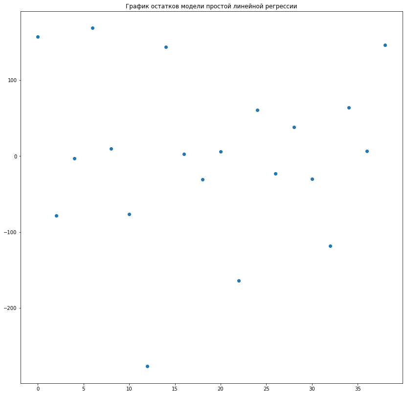

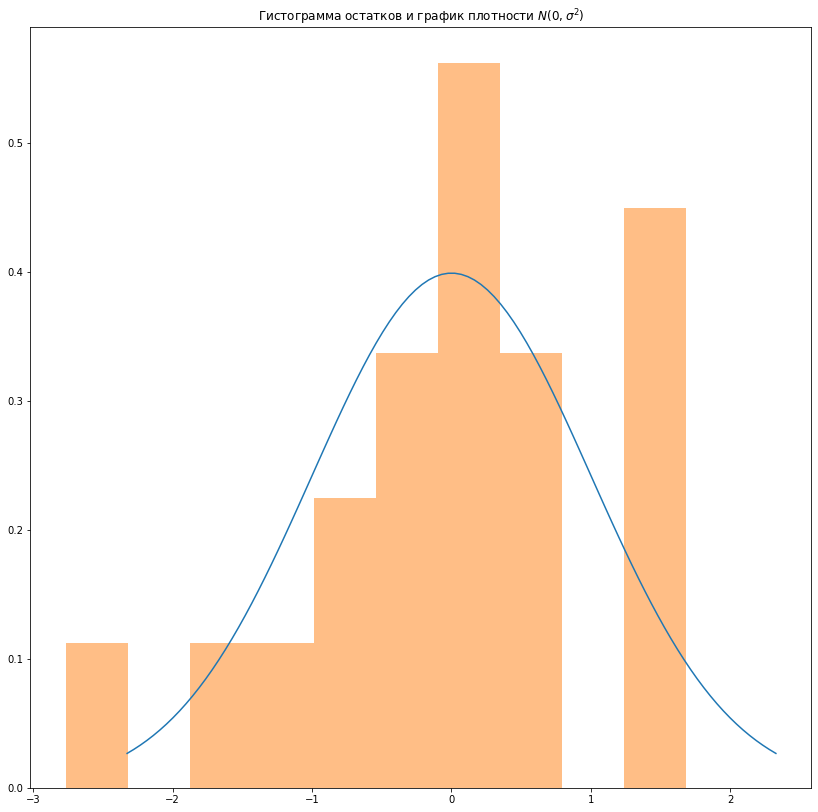

```python
import scipy.stats as stats
plt.figure(figsize=(14,14))
plt.scatter(t,E)
plt.title("График остатков модели простой линейной регрессии")
plt.show()

x = np.linspace(stats.norm.ppf(0.01),
                stats.norm.ppf(0.99), 100)

plt.figure(figsize=(14,14))
plt.plot(x, stats.norm.pdf(x))
plt.hist(E/100, density=True, histtype='stepfilled', alpha=0.5)
plt.title("Гистограмма остатков и график плотности $N(0, \sigma^2)$")
plt.show()
```

1. Аналогично и для случая параболической линейной регрессии

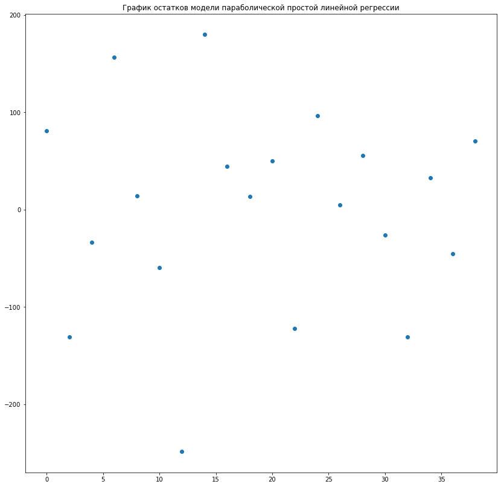

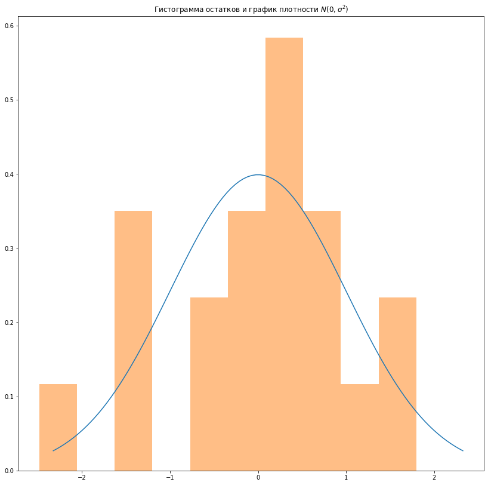

```python
plt.figure(figsize=(14,14))
plt.scatter(t, E2)
plt.title("График остатков модели параболической простой линейной регрессии")
plt.show()

#
x = np.linspace(stats.norm.ppf(0.01),
                stats.norm.ppf(0.99), 100)

plt.figure(figsize=(14,14))
plt.plot(x, stats.norm.pdf(x))
plt.hist(E2/100, density=True, histtype='stepfilled', alpha=0.5)
plt.title("Гистограмма остатков и график плотности $N(0, \sigma^2)$")
plt.show()
```